# Impact of reference bundle on scRNA-Seq alignment

This the first part of analysis about the impact of reference bundle on scRNA-Seq alignment and gene quantifications. Alignment metrics have been parsed from `STAR` alignment log file `Final.out.log`. The metrics we will examine is `unique mapping reads`,`multiple mapping reads`, `reads mapped too many loci`, `total number of annotated junctions`.

First,load packages `ggplot2` and `plyr`

Now take a look at the `STAR` logs.

```r
ref_log<-read.delim('~/Documents/HCA/reference/ref_run_MGH30_logs.tsv',sep='\t',header=T)
head(ref_log)
```

|  | sraID | length | ref_name | Started.job.on | Started.mapping.on | Finished.on | Mapping.speed..Million.of.reads.per.hour | Number.of.input.reads | Average.input.read.length | Uniquely.mapped.reads.number | Uniquely.mapped.reads.. | Average.mapped.length | Number.of.splices..Total | Number.of.splices..Annotated..sjdb. | Number.of.splices..GT.AG | Number.of.splices..GC.AG | Number.of.splices..AT.AC | Number.of.splices..Non.canonical | Mismatch.rate.per.base... | Deletion.rate.per.base | Deletion.average.length | Insertion.rate.per.base | Insertion.average.length | Number.of.reads.mapped.to.multiple.loci | X..of.reads.mapped.to.multiple.loci | Number.of.reads.mapped.to.too.many.loci | X..of.reads.mapped.to.too.many.loci | X..of.reads.unmapped..too.many.mismatches | X..of.reads.unmapped..too.short | … |
| --- | --- | --- | --- | --- | --- | --- | --- | --- | --- | --- | --- | --- | --- | --- | --- | --- | --- | --- | --- | --- | --- | --- | --- | --- | --- | --- | --- | --- | --- | --- |
| 1 | SRR1294900 | 25 | GRCh38_Ensembl | Oct 26 22:08:13 | Oct 26 22:17:39 | Oct 26 22:18:41 | 243.37 | 4191367 | 50 | 3360247 | 80.17% | 49.81 | 277249 | 276651 | 274587 | 1943 | 410 | 309 | 0.16% | 0.00% | 1.21 | 0.00% | 1.00 | 264187 | 6.30% | 15174 | 0.36% | 0.00% | 11.89% | … |
| 2 | SRR1294893 | 25 | GRCh38_Ensembl | Oct 26 22:08:40 | Oct 26 22:17:57 | Oct 26 22:18:59 | 235.83 | 4061542 | 50 | 3267963 | 80.46% | 49.74 | 329227 | 328524 | 326350 | 1838 | 649 | 390 | 0.17% | 0.00% | 1.26 | 0.00% | 1.03 | 229468 | 5.65% | 12929 | 0.32% | 0.00% | 12.47% | … |
| 3 | SRR1294905 | 25 | GRCh38_Ensembl | Oct 26 22:08:51 | Oct 26 22:18:51 | Oct 26 22:19:46 | 222.83 | 3404352 | 50 | 2686070 | 78.90% | 49.69 | 295807 | 295464 | 293615 | 1650 | 253 | 289 | 0.16% | 0.00% | 1.17 | 0.00% | 1.01 | 224859 | 6.61% | 11790 | 0.35% | 0.00% | 13.19% | … |
| 4 | SRR1294971 | 25 | GRCh38_Ensembl | Oct 26 22:08:45 | Oct 26 22:18:17 | Oct 26 22:19:33 | 253.75 | 5356859 | 50 | 4272480 | 79.76% | 49.80 | 375911 | 375116 | 372265 | 2399 | 873 | 374 | 0.16% | 0.00% | 1.26 | 0.00% | 1.05 | 293883 | 5.49% | 23548 | 0.44% | 0.00% | 12.79% | … |
| 5 | SRR1294904 | 25 | GRCh38_Ensembl | Oct 26 22:08:43 | Oct 26 22:18:17 | Oct 26 22:19:19 | 231.13 | 3980622 | 50 | 3135504 | 78.77% | 49.71 | 311294 | 310784 | 308602 | 1949 | 403 | 340 | 0.16% | 0.00% | 1.23 | 0.00% | 1.03 | 254676 | 6.40% | 14564 | 0.37% | 0.00% | 13.29% | … |
| 6 | SRR1294935 | 25 | GRCh38_Ensembl | Oct 26 22:08:36 | Oct 26 22:18:15 | Oct 26 22:19:32 | 253.78 | 5428078 | 50 | 4243629 | 78.18% | 49.75 | 424671 | 423933 | 420773 | 2479 | 759 | 660 | 0.17% | 0.00% | 1.20 | 0.00% | 1.09 | 364879 | 6.72% | 41453 | 0.76% | 0.00% | 12.82% | … |

Then add string `bp` to column `length` and then rename of `ref_name`

```r
rlen<-paste(ref_log$length,'bp')
refname<-mapvalues(ref_log$ref_name,from=c('GRCh38_Ensembl','GRCh38_GencodeV27','GRCh38_GencodeV27_basic','GRCh38_RefSeq'),to=c('Ensembl','GencodeV27_comp','GencodeV27_basic','RefSeq'))
multi.loci<-unlist(lapply(ref_log$X..of.reads.mapped.to.multiple.loci, function(x) as.numeric(sub("%", "", x))))
ref_log$ref_name<-refname
ref_log$length<-rlen
```

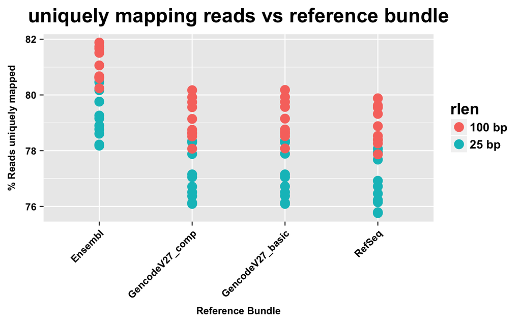

```r
uniq.mapped<-unlist(lapply(ref_log$Uniquely.mapped.reads.., function(x) as.numeric(sub("%", "", x))))
p<-ggplot(data=ref_log)+geom_point(mapping=aes(x=refname,y=uniq.mapped,color=rlen),size=4)
p<-p+xlab('Reference Bundle')+ylab('% Reads uniquely mapped')+ggtitle('uniquely mapping reads vs reference bundle')
p<-p+theme(plot.title = element_text(hjust = 0.5,size=20,face='bold'))
p<-p+theme(axis.title.x = element_text(color='black',size=10,face='bold'),axis.title.y = element_text(size=10,color='black',face='bold'))
p<-p+theme(axis.text.y = element_text(color='black',size=10,face='bold'),axis.text.x = element_text(color='black',size=10,face='bold',hjust=1,angle = 45))
p<-p+theme(legend.text=element_text(size=12,face='bold'),legend.title = element_text(face="bold"))
p
```

Now let’s plot `multiple mapping reads vs reference bundle`. `Ensembl` bundle actually show the lowest multiple mapping rate

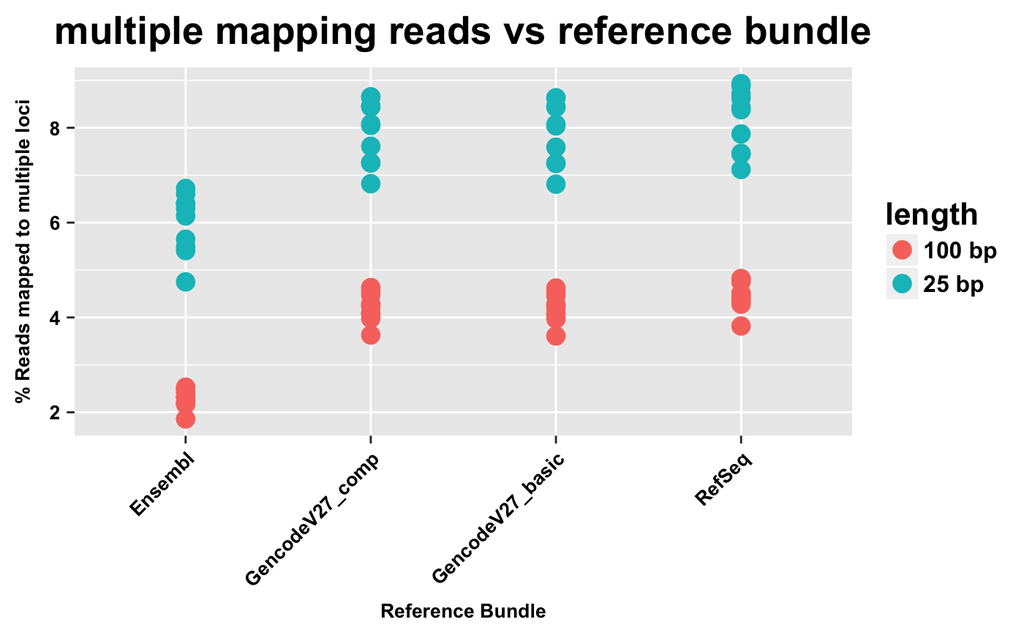

```r
multi.loci<-unlist(lapply(ref_log$X..of.reads.mapped.to.multiple.loci, function(x) as.numeric(sub("%", "", x))))
p<-ggplot(data=ref_log)+geom_point(mapping=aes(x=ref_name,y=multi.loci,color=length),size=4)
p<-p+xlab('Reference Bundle')+ylab('% Reads mapped to multiple loci')+ggtitle('multiple mapping reads vs reference bundle')
p<-p+theme(plot.title = element_text(hjust = 0.5,size=20,face='bold'))
p<-p+theme(axis.title.x = element_text(color='black',size=10,face='bold'),axis.title.y = element_text(size=10,color='black',face='bold'))
p<-p+theme(axis.text.y = element_text(color='black',size=10,face='bold'),axis.text.x = element_text(color='black',size=10,face='bold',hjust=1,angle = 45))
p<-p+theme(legend.text=element_text(size=12,face='bold'),legend.title = element_text(face="bold"))
p
```

Then `reads mapped too many loci vs reference bundle`. `Ensembl` bundle show slightly low rate of `reads mapped too many loci`

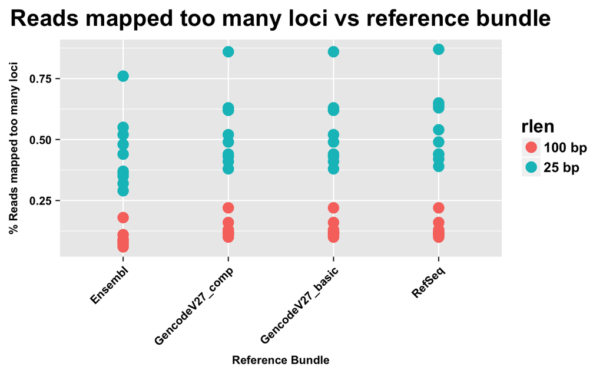

```r
too.many<-unlist(lapply(ref_log$X..of.reads.mapped.to.too.many.loci, function(x) as.numeric(sub("%", "", x))))
p<-ggplot(data=ref_log)+geom_point(mapping=aes(x=refname,y=too.many,color=rlen),size=4)
p<-p+xlab('Reference Bundle')+ylab('% Reads mapped too many loci')+ggtitle('Reads mapped too many loci vs reference bundle')
p<-p+theme(plot.title = element_text(hjust = 0.5,size=20,face='bold'))
p<-p+theme(axis.title.x = element_text(color='black',size=10,face='bold'),axis.title.y = element_text(size=10,color='black',face='bold'))
p<-p+theme(axis.text.y = element_text(color='black',size=10,face='bold'),axis.text.x = element_text(color='black',size=10,face='bold',hjust=1,angle = 45))
p<-p+theme(legend.text=element_text(size=12,face='bold'),legend.title = element_text(face="bold"))
p
```

What if the `annotated splicing junction` ?

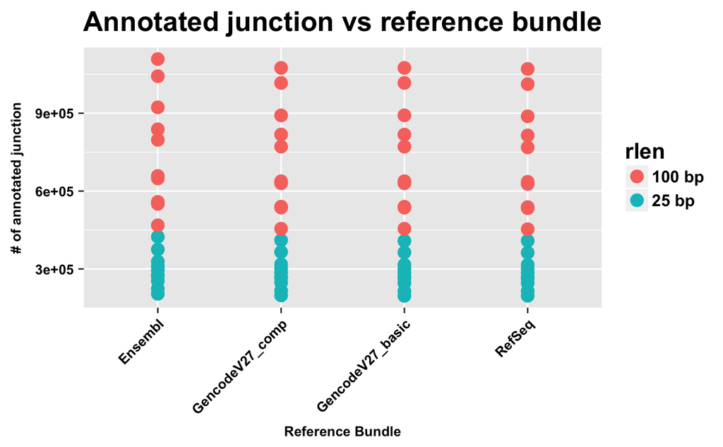

```r
junction<-ref_log$Number.of.splices..Annotated..sjdb.
p<-ggplot(data=ref_log)+geom_point(mapping=aes(x=refname,y=junction,color=rlen),size=4)
p<-p+xlab('Reference Bundle')+ylab('# of annotated junction')+ggtitle('Annotated junction vs reference bundle')
p<-p+theme(plot.title = element_text(hjust = 0.5,size=20,face='bold'))
p<-p+theme(axis.title.x = element_text(color='black',size=10,face='bold'),axis.title.y = element_text(size=10,color='black',face='bold'))
p<-p+theme(axis.text.y = element_text(color='black',size=10,face='bold'),axis.text.x = element_text(color='black',size=10,face='bold',hjust=1,angle = 45))
p<-p+theme(legend.text=element_text(size=12,face='bold'),legend.title = element_text(face="bold"))
p
```

`total splices` include `annotated` and `not annotated` junctions

[figure not shown]

```r
splices<-ref_log$Number.of.splices..Total
p<-ggplot(data=ref_log)+geom_point(mapping=aes(x=refname,y=junction,color=rlen),size=4)
p<-p+xlab('Reference Bundle')+ylab('# of Total Splices')+ggtitle('Total Splices vs reference bundle')
p<-p+theme(plot.title = element_text(hjust = 0.5,size=20,face='bold'))
p<-p+theme(axis.title.x = element_text(color='black',size=10,face='bold'),axis.title.y = element_text(size=10,color='black',face='bold'))
p<-p+theme(axis.text.y = element_text(color='black',size=10,face='bold'),axis.text.x = element_text(color='black',size=10,face='bold',hjust=1,angle = 45))
p<-p+theme(legend.text=element_text(size=12,face='bold'),legend.title = element_text(face="bold"))
p
```